# EX04

Reed Scott & Lindsey Pekurny

18 February 2022

## This exercise links to Module 2.4

Submit the completed exercise to us at:

- t.edwards@usu.edu
- eric_tsakiris@fws.gov

## Context

The data are of the *Pinus edulis* Common piñon, the species you dealt with in Exercise #3. In this exercise we assume the acquisition of species location data reveals that data are presence-only (measured 1’s only; no 0=absence)

The goal is to build a dataframe consisting of pseudo–absences selected from *edulis*’ geographic and environmental background.

### The Twist to this Exercise

There’s a twist to what you will do in exercises starting now, with all subsequent exercises being group–based. You can self–organize into groups, or I can assign you to a group. Groups are on the order of 2–4 individuals.

- **IMPORTANT**: If you wish to self–organize do that quickly and let Eric and I know ASAP. You will need to provide the name and email address of those in your group. Pick a leader to act as the principal POC.

Each group will be assigned one type of data, as descried below. Once assigned a type of data, you will use those data for the rest of the class.

The data for *edulis* have four discrete labels:

- **Seedlings**: these data indicate spatial locations where seedlings of the tree have been found
- **Mortality**: these data indicate spatial locations where mortality has been observed
- **Persistence**: these data have no observed mortality or seedling at given spatial locations
- **Range**: the total dataset, including all spatial locations of seedlings, mortality, and persistence

## The Data

- Common piñon *Pinus edulis* sppcode=106
- Data for each group in:
  - **`~\sdhmR-V2022.1\data\exercise\traindat`**
- Data files:
  - **`spp106pr_MORT.csv`**, **`spp106pr_PERS.csv`**, **`spp106pr_RANG.csv`**, **`spp106pr_SEED.csv`**

**Global options and loading data**

```r
#Setting Paths
path.root <- "D:/OneDrive - University of Vermont/Classes/Spring2022/sdhmR/sdhmR-V2022.1"
path.ex <- paste(path.root, "/data/exercise/traindat", sep = "") #Path to mod 2
path.figs <- paste(path.root, "/powerpoints/figures", sep = "") #path to save figs
path.gis <- paste(path.root, "/data/gis_layers", sep = "") #path to gis files

# some libraries
library(raster) # FXNS: extent, raster, res, rasterize, values, writeRaster,
#       cellFromXY, extract
library(sf)     # FXNS: st_as_sf, st_as_sfc, st_bbox, st_convex_hull, st_union
#       st_buffer, st_read, st_write, st_intersection, st_geometry,
#       st_drop_geometry, st_coordinates, st_sf
library(terra)  # FXNS: as.data.frame, rast, vect
library(sp)

# source course CRSs
setwd(path.root)
source("r_code/prjs4_sdhmR.r") # source course CRSs
ls(pattern = "prj.") # should be 5 prj.* objects
```

```
## [1] "prj.aeaN83"    "prj.gmerc"     "prj.latlong"   "prj.utmWGSz12"
## [5] "prj.wgs84"
```

## Question #1

- Import the data type you have been assigned to work with
- Build a buffered-presence points bounding box
  - Buffer each point by ~50km
  - **CAUTION**: make sure the pluses and minuses when buffering are in the correct direction given north, south, east, and west !! (Serious screw-ups happen here …)
- Ensure you assign correct CRS, values, and resolution to bounding box

```r
setwd(path.ex)
pers <- read.csv('spp106pr_PERS.csv')
head(pers, 2)
```

```
##            UNIQUEID    wgs_xF   wgs_yF PERS106 exp5nrm exp3nrm rough_1k
## 1 Z0401030101188321 -109.3904 33.25027       1     105      60 29.65390
## 2 Z0401030101190680 -109.2267 33.38345       1    -101    -122 55.21476
##   prad_sw_di etpt_5 mind_yr_av prec_winte tave_sprin
## 1      -5768     94  -1577.083   40.33333         98
## 2      -5688     95  -1625.917   36.00000        109
```

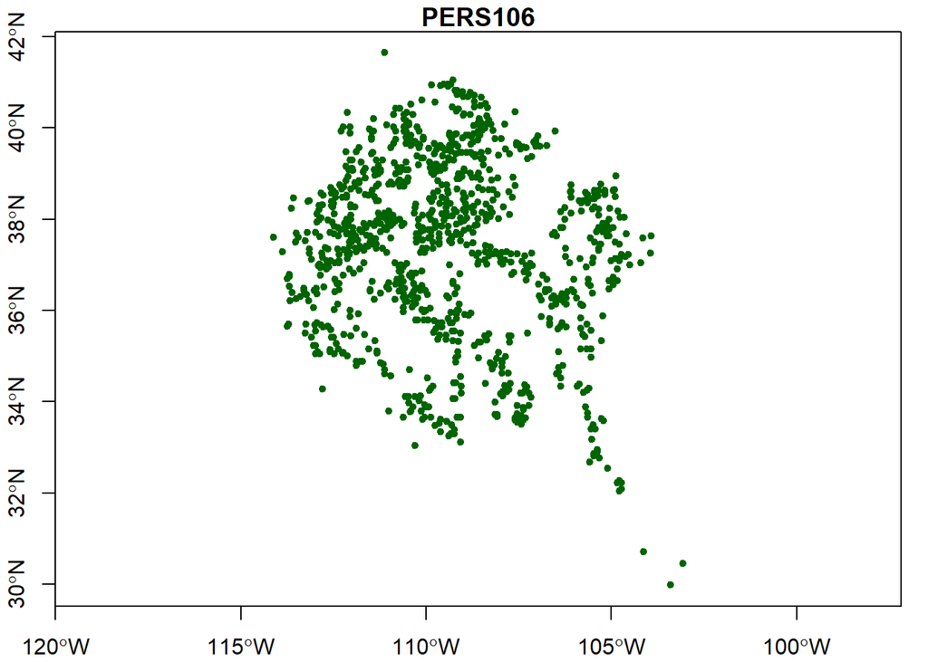

```r
persSF <- st_as_sf(pers, coords = c('wgs_xF', 'wgs_yF'), crs = prj.wgs84)
plot(persSF['PERS106'], col = "darkgreen", pch = 20, axes = T)
```

```r
#Build a buffered presence bbox
extb <- extent(min(pers$wgs_xF) - 0.5, max(pers$wgs_xF) + 0.5,
               min(pers$wgs_yF) - 0.5, max(pers$wgs_yF) + 0.5)
# create .5 decideg buffered poly
pers.bufSF <- st_as_sfc(st_bbox(extb, crs = prj.wgs84))
pers.bufSF # examine
```

```
## Geometry set for 1 feature
## Geometry type: POLYGON
## Dimension:     XY
## Bounding box:  xmin: -114.6124 ymin: 29.4878 xmax: -102.5687 ymax: 42.14354
## CRS:           +proj=longlat +ellps=WGS84 +datum=WGS84 +no_defs
```

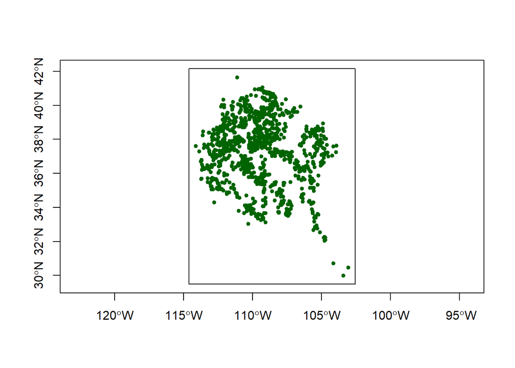

```r
plot(st_geometry(pers.bufSF), axes = T) # NOT RUN
plot(persSF['PERS106'], col = "darkgreen", pch = 20, axes = T, add = T)
```

## Question #2

- Build a fishnet for the bounding box

```r
setwd(path.gis)
t1 <- raster("templateR_wgs.img") # alternative; import wgs84 template
pers.bufSP <- as_Spatial(pers.bufSF)
pers.bufR <- crop(rasterize(pers.bufSP, t1), pers.bufSP)

# extract coords, cell id of coords, & build dataframe
f1 <- sp::coordinates(pers.bufR) # get spatial coords from pied.bufR
f2 <- cellFromXY(pers.bufR, f1) # extract cell number from buffered extent
f3 <- as.data.frame(cbind(f1, f2)) # build datframe of x,y & cell number
head(f3, 2) # examine
```

```
##           x        y f2
## 1 -114.6065 42.14331  1
## 2 -114.5982 42.14331  2
```

```r
tail(f3, 1) # f2 value should = ncell in pers.bufR; below
```

```
##                 x        y      f2
## 2197920 -102.5697 29.49004 2197920
```

```r
ncell(pers.bufR) # should = f2 value above
```

```
## [1] 2197920
```

```r
names(f3)[1:3] <- c("cell.wgs_x", "cell.wgs_y", "FNETID") # assign names
f3 <- f3[c("FNETID", "cell.wgs_x", "cell.wgs_y")] # reorder

#Examine
dim(f3) # dimension; rows is maximum number of cells in fishnet
```

```
## [1] 2197920       3
```

```r
names(f3) # names in fishnet
```

```
## [1] "FNETID"     "cell.wgs_x" "cell.wgs_y"
```

```r
head(f3) #examine
```

```
##   FNETID cell.wgs_x cell.wgs_y
## 1      1  -114.6065   42.14331
## 2      2  -114.5982   42.14331
## 3      3  -114.5898   42.14331
## 4      4  -114.5815   42.14331
## 5      5  -114.5732   42.14331
## 6      6  -114.5649   42.14331
```

```r
tail(f3)
```

```
##          FNETID cell.wgs_x cell.wgs_y
## 2197915 2197915  -102.6113   29.49004
## 2197916 2197916  -102.6030   29.49004
## 2197917 2197917  -102.5946   29.49004
## 2197918 2197918  -102.5863   29.49004
## 2197919 2197919  -102.5780   29.49004
## 2197920 2197920  -102.5697   29.49004
```

```r
#convert to spatial object
pers.fnetSF <- st_as_sf(f3, coords = c("cell.wgs_x", "cell.wgs_y"),
                        crs = prj.wgs84, remove = F) # remove=F retains input x,y)
head(pers.fnetSF, 2) # examine
```

```
## Simple feature collection with 2 features and 3 fields
## Geometry type: POINT
## Dimension:     XY
## Bounding box:  xmin: -114.6065 ymin: 42.14331 xmax: -114.5982 ymax: 42.14331
## CRS:           +proj=longlat +ellps=WGS84 +datum=WGS84 +no_defs
##   FNETID cell.wgs_x cell.wgs_y                   geometry
## 1      1  -114.6065   42.14331 POINT (-114.6065 42.14331)
## 2      2  -114.5982   42.14331 POINT (-114.5982 42.14331)
```

```r
# build stand-alone dataframe
class(pers.fnetSF) # note dataframe class; will extract data.frame
```

```
## [1] "sf"         "data.frame"
```

```r
pers.fnetDF <- st_drop_geometry(pers.fnetSF) # build dataframe
head(pers.fnetDF, 2) # examine
```

```
##   FNETID cell.wgs_x cell.wgs_y
## 1      1  -114.6065   42.14331
## 2      2  -114.5982   42.14331
```

```r
class(pers.fnetDF) # check if class=data.frame
```

```
## [1] "data.frame"
```

```r
# export as esri shapefile & dataframe
setwd(path.ex) # output path
st_write(pers.fnetSF, dsn = ".", layer = "pied_fnetSF", driver = "ESRI Shapefile",
         delete_layer = T, delete_dsn = T) # output shapefile
```

```
## Deleting source `.' using driver `ESRI Shapefile'
## Writing layer `pied_fnetSF' to data source `.' using driver `ESRI Shapefile'
## Writing 2197920 features with 3 fields and geometry type Point.
```

```r
# save objects
setwd(path.ex) # output path
save("pers.fnetSF", "pers.fnetDF", file = "pers.fnet.RData")
```

## Question #3

- Use the fishnet to create a pseudo–absence data frame of [X,Y]’s
- For simplicity’s sake, set $n$ for pseudo–absence at twice (2$\times$) the number of presences in your respective RANG, PERS, MORT, and SEED data set
- Bind these data to the presence dataframe you imported in Question #1

```r
pers.xy <- pers[c("wgs_xF", "wgs_yF")]  # get x,y of species presences
p1 <- sp::coordinates(pers.xy) # set spatial coords from pied.bufptR

# extract FNETID of presence from  modelling frame
pers.fnetid <- cellFromXY(pers.bufR, p1)
head(pers.fnetid)
```

```
## [1] 1544955 1521839 1536286 1474128 1568129 1582441
```

```r
#checks
length(pers.fnetid) # should match number of presences ??
```

```
## [1] 986
```

```r
length(pers$PERS106) # it does ... life is good !!
```

```
## [1] 986
```

```r
# create species dataframe with FNETIDs
tru.persFNET <- cbind(pers.fnetid, pers) # add fishnet ID to tru.pres
names(tru.persFNET)[1] <- "FNETID" # name change
head(tru.persFNET, 2) # examine
```

```
##    FNETID          UNIQUEID    wgs_xF   wgs_yF PERS106 exp5nrm exp3nrm rough_1k
## 1 1544955 Z0401030101188321 -109.3904 33.25027       1     105      60 29.65390
## 2 1521839 Z0401030101190680 -109.2267 33.38345       1    -101    -122 55.21476
##   prad_sw_di etpt_5 mind_yr_av prec_winte tave_sprin
## 1      -5768     94  -1577.083   40.33333         98
## 2      -5688     95  -1625.917   36.00000        109
```

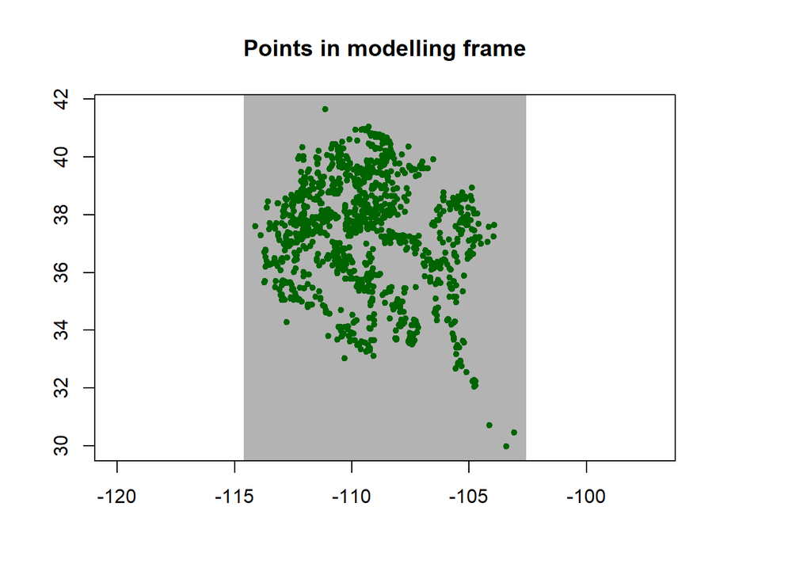

```r
# giggle plots
plot(pers.bufR, col = "gray70",
     legend = F,
     main = "Points in modelling frame")  # main plot
points(pers$wgs_xF,
       pers$wgs_yF,
       pch = 20,
       col = "darkgreen") # add spp locations
```

```r
#extract fnetid
buf.fnetid <- extract(pers.bufR, pers.fnetDF[c("cell.wgs_x", "cell.wgs_y")])

# create modelling dataframe with FNETIDs
tru.bufFNET <- cbind(pers.fnetDF, buf.fnetid) # bind modelling frame w/FISHNET
head(tru.bufFNET, 2) # examine
```

```
##   FNETID cell.wgs_x cell.wgs_y buf.fnetid
## 1      1  -114.6065   42.14331          1
## 2      2  -114.5982   42.14331          1
```

```r
# some internal checking
length(tru.bufFNET$buf.fnetid) # number FNETIDs in tru.bufFNET
```

```
## [1] 2197920
```

```r
ncell(pers.bufR) # should equal above
```

```
## [1] 2197920
```

```r
table(tru.bufFNET$buf.fnetid)[[1]] # number of FNETIDs in pied.bufptR
```

```
## [1] 2197920
```

```r
length(which(is.na(tru.bufFNET$bufpt.fnetid))) # No. NAs
```

```
## [1] 0
```

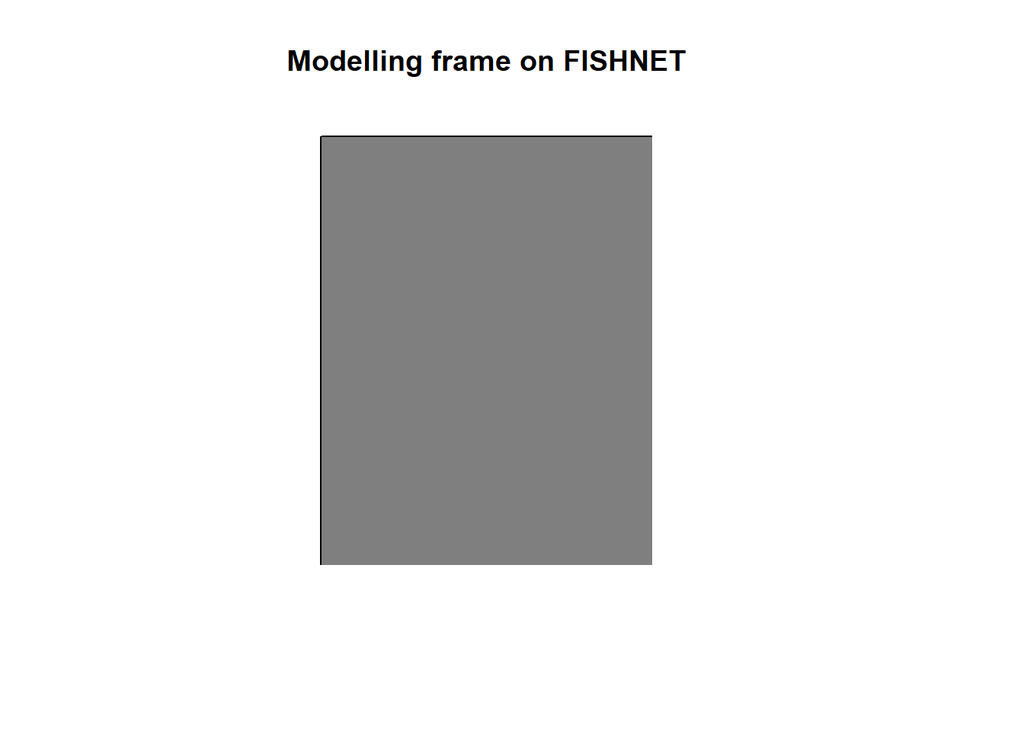

```r
# giggle plots: modelling frames nested in fishnet
plot(pers.bufSP, col = "gray90", legend = F, main = "Modelling frame on FISHNET")  # main plot
plot(pers.bufR, col = "gray50", legend = F, add = T)  # main plot
```

[figure not shown]

```r
# giggle plots: spp location nested in modelling frames nested in fishnet
plot(pers.bufSP, col = "gray90",
     main = "SP locations nested in modelling frame in FISHNET")  # main plot
points(pers$wgs_xF, pers$wgs_yF, pch = 20, col = "darkgreen") # spp locations if desired
plot(pers.bufR, col = "gray50", legend = F, add = T)  # main plot
```

```r
######## START MERGE SPP LOCATION, MODELLING FRAME, ALL BY FISHNET ID'S
# examine dataframes
head(pers.fnetDF, 2) # fishnet dataframe
```

```
##   FNETID cell.wgs_x cell.wgs_y
## 1      1  -114.6065   42.14331
## 2      2  -114.5982   42.14331
```

```r
dim(pers.fnetDF)[1] # size of fishnet dataframe
```

```
## [1] 2197920
```

```r
head(tru.bufFNET, 2) # modelling dataframe
```

```
##   FNETID cell.wgs_x cell.wgs_y buf.fnetid
## 1      1  -114.6065   42.14331          1
## 2      2  -114.5982   42.14331          1
```

```r
table(tru.bufFNET$buf.fnetid)[[1]] # number of FNETIDs in pied.bufptR
```

```
## [1] 2197920
```

```r
head(tru.bufFNET, 2) # spp locations dataframe
```

```
##   FNETID cell.wgs_x cell.wgs_y buf.fnetid
## 1      1  -114.6065   42.14331          1
## 2      2  -114.5982   42.14331          1
```

```r
dim(tru.bufFNET)[1] # number spp locations
```

```
## [1] 2197920
```

```r
# begin merge: NOTE merge by=c("sort vars") & all.y=T options
m1 <- merge(pers.fnetDF, tru.bufFNET, by = c("FNETID", "cell.wgs_x", "cell.wgs_y"), all.y = T)
head(m1, 2) # examine: FNETID no longer ranked but not to worry ...
```

```
##   FNETID cell.wgs_x cell.wgs_y buf.fnetid
## 1      1  -114.6065   42.14331          1
## 2     10  -114.5315   42.14331          1
```

```r
pers.indexFNET <- merge(m1, tru.persFNET, by = c("FNETID"), all = T) # final merge:assign DF name
head(pers.indexFNET, 2) # final merge: FNETID now ranked
```

```
##   FNETID cell.wgs_x cell.wgs_y buf.fnetid UNIQUEID wgs_xF wgs_yF PERS106
## 1      1  -114.6065   42.14331          1     <NA>     NA     NA      NA
## 2      2  -114.5982   42.14331          1     <NA>     NA     NA      NA
##   exp5nrm exp3nrm rough_1k prad_sw_di etpt_5 mind_yr_av prec_winte tave_sprin
## 1      NA      NA       NA         NA     NA         NA         NA         NA
## 2      NA      NA       NA         NA     NA         NA         NA         NA
```

```r
names(pers.indexFNET)[4] <- "in.modFR" # change some names
names(pers.indexFNET) # examine names
```

```
##  [1] "FNETID"     "cell.wgs_x" "cell.wgs_y" "in.modFR"   "UNIQUEID"
##  [6] "wgs_xF"     "wgs_yF"     "PERS106"    "exp5nrm"    "exp3nrm"
## [11] "rough_1k"   "prad_sw_di" "etpt_5"     "mind_yr_av" "prec_winte"
## [16] "tave_sprin"
```

```r
# internal checking
length(pers.indexFNET$FNETID) # does it match w/above ?? yes !
```

```
## [1] 2197920
```

```r
table(pers.indexFNET$in.modFR)[[1]] # does it match w/above ?? yes !
```

```
## [1] 2197920
```

```r
table(pers.indexFNET$PERS106)[[1]] # does it match w/above ?? yes !
```

```
## [1] 986
```

```r
names(pers.indexFNET) # names make sense ?? yes !
```

```
##  [1] "FNETID"     "cell.wgs_x" "cell.wgs_y" "in.modFR"   "UNIQUEID"
##  [6] "wgs_xF"     "wgs_yF"     "PERS106"    "exp5nrm"    "exp3nrm"
## [11] "rough_1k"   "prad_sw_di" "etpt_5"     "mind_yr_av" "prec_winte"
## [16] "tave_sprin"
```

```r
# outfile final fnet index dataframe
setwd(path.ex)
save(pers.indexFNET, file = "pers.indexFNET.RData")

# examine the fishnet
head(pers.indexFNET)
```

```
##   FNETID cell.wgs_x cell.wgs_y in.modFR UNIQUEID wgs_xF wgs_yF PERS106 exp5nrm
## 1      1  -114.6065   42.14331        1     <NA>     NA     NA      NA      NA
## 2      2  -114.5982   42.14331        1     <NA>     NA     NA      NA      NA
## 3      3  -114.5898   42.14331        1     <NA>     NA     NA      NA      NA
## 4      4  -114.5815   42.14331        1     <NA>     NA     NA      NA      NA
## 5      5  -114.5732   42.14331        1     <NA>     NA     NA      NA      NA
## 6      6  -114.5649   42.14331        1     <NA>     NA     NA      NA      NA
##   exp3nrm rough_1k prad_sw_di etpt_5 mind_yr_av prec_winte tave_sprin
## 1      NA       NA         NA     NA         NA         NA         NA
## 2      NA       NA         NA     NA         NA         NA         NA
## 3      NA       NA         NA     NA         NA         NA         NA
## 4      NA       NA         NA     NA         NA         NA         NA
## 5      NA       NA         NA     NA         NA         NA         NA
## 6      NA       NA         NA     NA         NA         NA         NA
```

```r
##################################################3
#Extracting pseduo absence
# create conditional vectors: FNETIDs by spp locations & in modelling frame
p2.spp <- subset(pers.indexFNET$FNETID, pers.indexFNET$PERS106 == 1) # FNETIDs of spp locations
p2.modFR <- subset(pers.indexFNET$FNETID, pers.indexFNET$in.modFR == 1) # FNETIDs in modelling frame
length(p2.spp) # should equal N of spp locations
```

```
## [1] 986
```

```r
length(p2.modFR) # should equal N modelling frame
```

```
## [1] 2197920
```

```r
# drop presence cell FNETIDs; remaining are possible psuedo-abs cell FNETIDs
p3 <- pers.indexFNET[!pers.indexFNET$FNETID %in% p2.spp, ] # background from fishnet
p4 <- pers.indexFNET[!pers.indexFNET$FNETID %in% p2.spp & pers.indexFNET$FNETID %in% p2.modFR, ] # background from modelling frame
pers.bufpt <- p4 # new name to dataframe: this dataframe used from now on

# internal checking
length(pers.indexFNET$FNETID) # N of FISHNET
```

```
## [1] 2197920
```

```r
dim(p3)[1] # N of FISHNET - N spp locations
```

```
## [1] 2196934
```

```r
table(pers.indexFNET$PERS106)[[1]] # N spp locations
```

```
## [1] 986
```

```r
dim(p3)[1] + table(pers.indexFNET$PERS106)[[1]] # should equal N of FISHNET
```

```
## [1] 2197920
```

```r
length(p2.modFR) # N of modelling frame
```

```
## [1] 2197920
```

```r
dim(p4)[1] # N modelling frame - N spp locations
```

```
## [1] 2196934
```

```r
dim(p4)[1] + table(pers.indexFNET$PERS106)[[1]] # should equal N modelling frame
```

```
## [1] 2197920
```

```r
# start the draws; multiple options shown below
#   NOTE: set seed if desire repeatability of srs
set.seed(1234) # set seed to ensure repeatability: make sure you remember what it is !!
pers.srs1 <- pers.bufpt[sample(1:nrow(pers.bufpt),
                               table(pers.indexFNET$PERS106)[[1]], replace = F), ]
pers.srs1$PERS106 <- 0 # assign 0 to pers.abs
pers.srs1$in.modFR <- 1 # assign 1 to in.modFR
dim(pers.srs1) # dim[1] should equal N spp locations, dim[2] the No. variables
```

```
## [1] 986  16
```

```r
head(pers.srs1, 2) # examine
```

```
##          FNETID cell.wgs_x cell.wgs_y in.modFR UNIQUEID wgs_xF wgs_yF PERS106
## 1811239 1811239  -107.5593   31.71415        1     <NA>     NA     NA       0
## 295872   295872  -107.2178   40.44399        1     <NA>     NA     NA       0
##         exp5nrm exp3nrm rough_1k prad_sw_di etpt_5 mind_yr_av prec_winte
## 1811239      NA      NA       NA         NA     NA         NA         NA
## 295872       NA      NA       NA         NA     NA         NA         NA
##         tave_sprin
## 1811239         NA
## 295872          NA
```

```r
# start the draws; multiple options shown below
#   N=2*No. pers
set.seed(1234) # set seed to ensure repeatability
pers.srs2 <- pers.bufpt[sample(1:nrow(pers.bufpt), 2 * table(pers.indexFNET$PERS106)[[1]], replace = F), ]
pers.srs2$PERS106 <- 0  # assign 0 to PERS.abs
pers.srs2$in.modFR <- 1  # assign 1 to in.modFR


######## START MERGE PSEUDO-ABS WITH TRUE PRESENCE DATAFRAME
# merge with true presences for predictor extraction
head(tru.persFNET, 2)
```

```
##    FNETID          UNIQUEID    wgs_xF   wgs_yF PERS106 exp5nrm exp3nrm rough_1k
## 1 1544955 Z0401030101188321 -109.3904 33.25027       1     105      60 29.65390
## 2 1521839 Z0401030101190680 -109.2267 33.38345       1    -101    -122 55.21476
##   prad_sw_di etpt_5 mind_yr_av prec_winte tave_sprin
## 1      -5768     94  -1577.083   40.33333         98
## 2      -5688     95  -1625.917   36.00000        109
```

```r
head(pers.srs1, 2) # examine; both MUST have FNETID
```

```
##          FNETID cell.wgs_x cell.wgs_y in.modFR UNIQUEID wgs_xF wgs_yF PERS106
## 1811239 1811239  -107.5593   31.71415        1     <NA>     NA     NA       0
## 295872   295872  -107.2178   40.44399        1     <NA>     NA     NA       0
##         exp5nrm exp3nrm rough_1k prad_sw_di etpt_5 mind_yr_av prec_winte
## 1811239      NA      NA       NA         NA     NA         NA         NA
## 295872       NA      NA       NA         NA     NA         NA         NA
##         tave_sprin
## 1811239         NA
## 295872          NA
```

```r
pers.PPsA <- merge(tru.persFNET,
                   pers.srs1,
                   by = c("FNETID", "PERS106", "wgs_xF", "wgs_yF"),
                   all = T) # merge
pers.PPsA$in.modFR <- NULL # drop in.modFR index no longer needed
dim(pers.PPsA) # examine
```

```
## [1] 1972   24
```

```r
head(pers.PPsA, 2) # dim => No. pres + No. pers.abs
```

```
##   FNETID PERS106 wgs_xF wgs_yF UNIQUEID.x exp5nrm.x exp3nrm.x rough_1k.x
## 1   7174       0     NA     NA       <NA>        NA        NA         NA
## 2  12806       0     NA     NA       <NA>        NA        NA         NA
##   prad_sw_di.x etpt_5.x mind_yr_av.x prec_winte.x tave_sprin.x cell.wgs_x
## 1           NA       NA           NA           NA           NA  -103.0361
## 2           NA       NA           NA           NA           NA  -104.3023
##   cell.wgs_y UNIQUEID.y exp5nrm.y exp3nrm.y rough_1k.y prad_sw_di.y etpt_5.y
## 1   42.10999       <NA>        NA        NA         NA           NA       NA
## 2   42.07667       <NA>        NA        NA         NA           NA       NA
##   mind_yr_av.y prec_winte.y tave_sprin.y
## 1           NA           NA           NA
## 2           NA           NA           NA
```

```r
# create common x,y from tru pres and pseudo-abs x,y's
pers.PPsA[352:355, ] # note diff [X,Y] coords for pres=0 & =1
```

```
##     FNETID PERS106    wgs_xF   wgs_yF        UNIQUEID.x exp5nrm.x exp3nrm.x
## 352 474994       1 -108.7356 39.41428 Z0804020204590449       147       143
## 353 475001       1 -108.6776 39.41323 Z0804020404585163        29        13
## 354 476523       1 -108.0394 39.39875 Z0804020604589594       -97      -114
## 355 477625       0        NA       NA              <NA>        NA        NA
##     rough_1k.x prad_sw_di.x etpt_5.x mind_yr_av.x prec_winte.x tave_sprin.x
## 352   35.92286        -6035       92    -1284.500     25.00000     64.33333
## 353   44.03769        -6103       91    -1235.417     26.33333     62.00000
## 354   39.87870        -6140       91    -1272.917     27.66667     71.33333
## 355         NA           NA       NA           NA           NA           NA
##     cell.wgs_x cell.wgs_y UNIQUEID.y exp5nrm.y exp3nrm.y rough_1k.y
## 352         NA         NA       <NA>        NA        NA         NA
## 353         NA         NA       <NA>        NA        NA         NA
## 354         NA         NA       <NA>        NA        NA         NA
## 355   -110.908   39.39441       <NA>        NA        NA         NA
##     prad_sw_di.y etpt_5.y mind_yr_av.y prec_winte.y tave_sprin.y
## 352           NA       NA           NA           NA           NA
## 353           NA       NA           NA           NA           NA
## 354           NA       NA           NA           NA           NA
## 355           NA       NA           NA           NA           NA
```

```r
# create new vars wgs_x & wgs_y; used later in raster stack extraction
pers.PPsA$tr.wgs_x <- ifelse(pers.PPsA$PERS106 == 0, pers.PPsA$cell.wgs_x, pers.PPsA$wgs_xF)
pers.PPsA$tr.wgs_y <- ifelse(pers.PPsA$PERS106 == 0, pers.PPsA$cell.wgs_y, pers.PPsA$wgs_yF)
pers.PPsA[352:355, ] # examine a subset
```

```
##     FNETID PERS106    wgs_xF   wgs_yF        UNIQUEID.x exp5nrm.x exp3nrm.x
## 352 474994       1 -108.7356 39.41428 Z0804020204590449       147       143
## 353 475001       1 -108.6776 39.41323 Z0804020404585163        29        13
## 354 476523       1 -108.0394 39.39875 Z0804020604589594       -97      -114
## 355 477625       0        NA       NA              <NA>        NA        NA
##     rough_1k.x prad_sw_di.x etpt_5.x mind_yr_av.x prec_winte.x tave_sprin.x
## 352   35.92286        -6035       92    -1284.500     25.00000     64.33333
## 353   44.03769        -6103       91    -1235.417     26.33333     62.00000
## 354   39.87870        -6140       91    -1272.917     27.66667     71.33333
## 355         NA           NA       NA           NA           NA           NA
##     cell.wgs_x cell.wgs_y UNIQUEID.y exp5nrm.y exp3nrm.y rough_1k.y
## 352         NA         NA       <NA>        NA        NA         NA
## 353         NA         NA       <NA>        NA        NA         NA
## 354         NA         NA       <NA>        NA        NA         NA
## 355   -110.908   39.39441       <NA>        NA        NA         NA
##     prad_sw_di.y etpt_5.y mind_yr_av.y prec_winte.y tave_sprin.y  tr.wgs_x
## 352           NA       NA           NA           NA           NA -108.7356
## 353           NA       NA           NA           NA           NA -108.6776
## 354           NA       NA           NA           NA           NA -108.0394
## 355           NA       NA           NA           NA           NA -110.9080
##     tr.wgs_y
## 352 39.41428
## 353 39.41323
## 354 39.39875
## 355 39.39441
```

## Question #4

- Save your data as R objects, including both the true presence and pseudo-absences:
  - Dataframe;
  - Point shapefile with geometry in R
  - Export as a point shapefile in ESRI format
- Save these R objects in a **`.RData`** file
- Save the bounding box as a raster–based **`.img`** file

```r
# resulting data frame is model training data set; outfile if desired
setwd(path.ex)
write.csv(pers.PPsA, file = "pers_PPsA.csv", row.names = F) # save .csv
save(pers.PPsA, file = "pers.PPsA.RData") # save .RData

writeRaster(pres.bufR,
            filename = paste(path.figs,"/pres.bufR.img", sep =''),
            options = c('TFW = YES'),
            overwrite = TRUE)
```

[output not shown]